# Lab 7: Optimal Management

Finally, let’s visualize our optimal solutions!

```r
(sites<-get_solution(pest_mod3, x[i,t]) %>%
  dplyr::filter(value == 1)) #show which of the sites were selected for insecticide treatment
```

```
##    variable  i t value
## 1         x 13 2     1
## 2         x 14 2     1
## 3         x 15 2     1
## 4         x 16 2     1
## 5         x 13 3     1
## 6         x 14 3     1
## 7         x 15 3     1
## 8         x 16 3     1
## 9         x 13 4     1
## 10        x 14 4     1
## 11        x 15 4     1
## 12        x 16 4     1
## 13        x 10 5     1
## 14        x 11 5     1
## 15        x 14 5     1
## 16        x 15 5     1
```

```r
(pest_den3<-matrix(get_solution(pest_mod3, p[i,t])$value, nrow=n, ncol=5)) #pest density after management in each cell
```

```
##            [,1]       [,2]       [,3]        [,4]       [,5]
##  [1,] 0.0000000 0.00000000 0.00000000 0.002950653 0.01415455
##  [2,] 0.0000000 0.00000000 0.00000000 0.002040666 0.01308569
##  [3,] 0.0000000 0.00000000 0.00000000 0.003324430 0.01719064
##  [4,] 0.0000000 0.00000000 0.00000000 0.002106514 0.01137632
##  [5,] 0.0000000 0.00000000 0.01475327 0.051028168 0.12430803
##  [6,] 0.0000000 0.00000000 0.01020333 0.046909360 0.10653634
##  [7,] 0.0000000 0.00000000 0.01662215 0.061859449 0.12662334
##  [8,] 0.0000000 0.00000000 0.01053257 0.040918078 0.10749954
##  [9,] 0.0000000 0.07376633 0.15641792 0.265511120 0.42725276
## [10,] 0.0000000 0.05101665 0.14195140 0.287207585 0.30182063
## [11,] 0.0000000 0.08311074 0.18882845 0.340776996 0.33993774
## [12,] 0.0000000 0.05266286 0.12477281 0.228023261 0.37857521
## [13,] 0.6156389 0.49361461 0.41027925 0.355871654 0.52176639
## [14,] 0.4865718 0.46297700 0.43239399 0.407028334 0.39787486
## [15,] 0.7167257 0.60234396 0.52109133 0.467046837 0.43677379
## [16,] 0.4628583 0.39908791 0.34862358 0.313010274 0.47094897
```

```r
objective_value(pest_mod3) # examine the objective value at the optimum
```

```
## [1] 13.54818
```

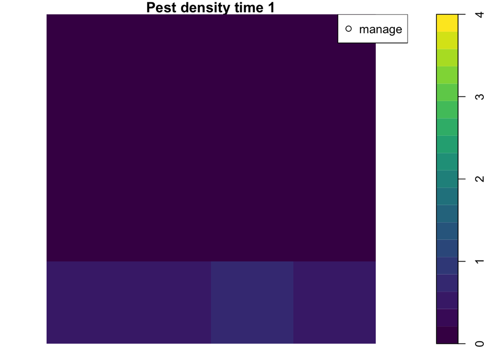

```r
plot(SpatialGridDataFrame(grid, data.frame(pest_den3[,1])), col=viridis(19), main="Pest density time 1",  breaks=seq(0,4,length.out=20)) # pest density after management
points(x=coordinates(grid)[sites$i[which(sites$t==1)],1], y=coordinates(grid)[sites$i[which(sites$t==1)],2], bg="white", pch=21, cex=3)
legend('topright',pch=21, legend=c("manage"), pt.bg=c('white'))
```

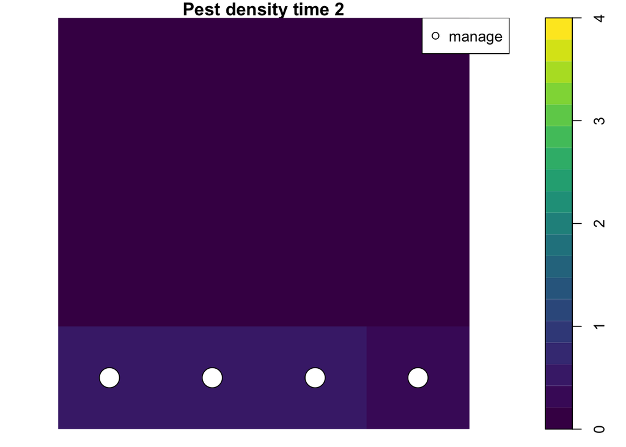

```r
plot(SpatialGridDataFrame(grid, data.frame(pest_den3[,2])), col=viridis(19), main="Pest density time 2",  breaks=seq(0,4,length.out=20)) # pest density after management
points(x=coordinates(grid)[sites$i[which(sites$t==2)],1], y=coordinates(grid)[sites$i[which(sites$t==2)],2], bg="white", pch=21, cex=3)
legend('topright',pch=21, legend=c("manage"), pt.bg=c('white'))
```

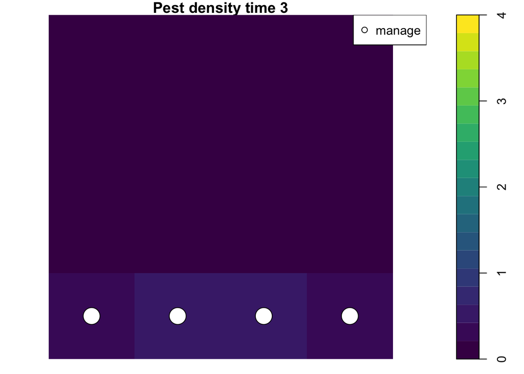

```r
plot(SpatialGridDataFrame(grid, data.frame(pest_den3[,3])), col=viridis(19), main="Pest density time 3",  breaks=seq(0,4,length.out=20)) # pest density after management
points(x=coordinates(grid)[sites$i[which(sites$t==3)],1], y=coordinates(grid)[sites$i[which(sites$t==3)],2], bg="white", pch=21, cex=3)
legend('topright',pch=21, legend=c("manage"), pt.bg=c('white'))
```

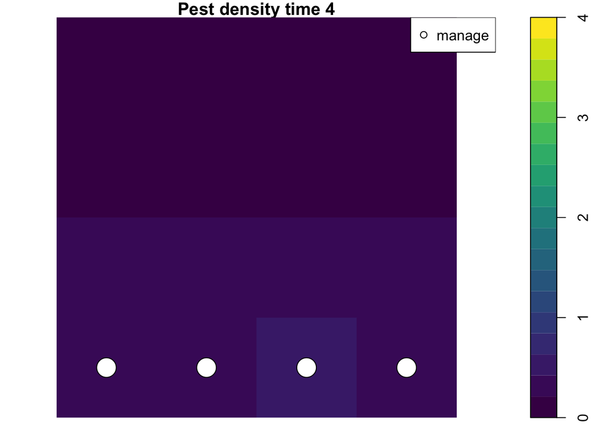

```r
plot(SpatialGridDataFrame(grid, data.frame(pest_den3[,4])), col=viridis(19), main="Pest density time 4",  breaks=seq(0,4,length.out=20)) # pest density after management
points(x=coordinates(grid)[sites$i[which(sites$t==4)],1], y=coordinates(grid)[sites$i[which(sites$t==4)],2], bg="white", pch=21, cex=3)
legend('topright',pch=21, legend=c("manage"), pt.bg=c('white'))
```

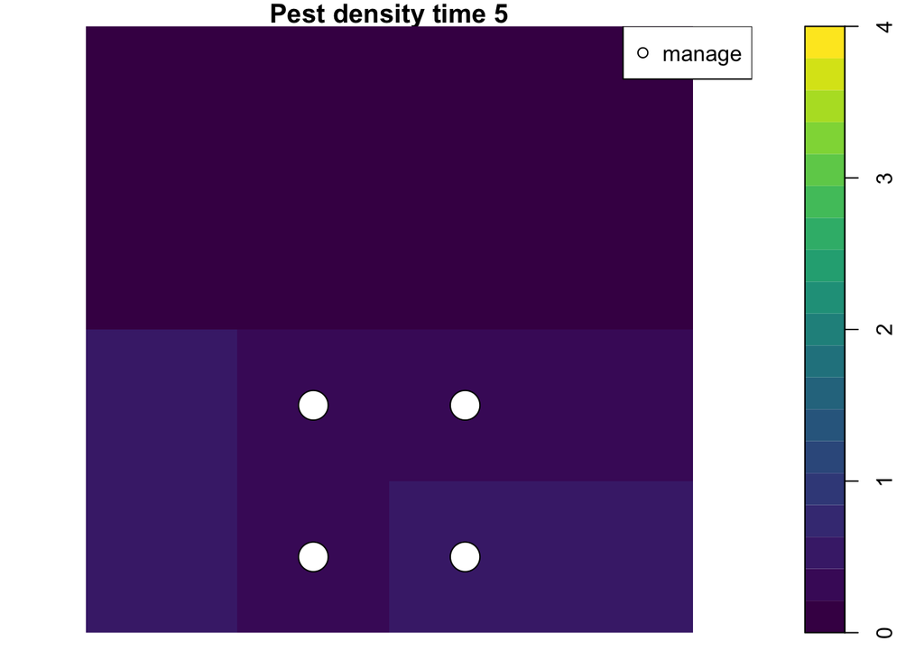

```r
plot(SpatialGridDataFrame(grid, data.frame(pest_den3[,5])), col=viridis(19), main="Pest density time 5",  breaks=seq(0,4,length.out=20)) # pest density after management
points(x=coordinates(grid)[sites$i[which(sites$t==5)],1], y=coordinates(grid)[sites$i[which(sites$t==5)],2], bg="white", pch=21, cex=3)
legend('topright',pch=21, legend=c("manage"), pt.bg=c('white'))
```

The impact of management is best viewed by comparing the above with the outcome of an optimization where the management budget forced to 0.

```r
pest_mod_nobudget <- MIPModel() %>%
  add_variable(x[i,t], i = 1:n, t=1:5,type = "binary") %>%  # define decision variable x as binary
  add_variable(p[i,t], i = 1:n, t=1:5,type = "continuous", lb=0, ub=M) %>%  # define the pest density variable as a continuous value between 0 and 1
 add_variable(v[i,t], i = 1:n, t=1:5,type = "continuous", lb=0, ub=M) %>%  # define your linearized variable v similar to p
  add_constraint(p[i,t]>=0.6*p[i,t-1]*r-0.6*e*r*v[i,t]+r*sum_expr(0.1*A[j,i]*p[j,t-1]-0.1*A[j,i]*e*v[j,t], j=1:n), i=1:n, t=2:5) %>%  # effect of management on pest density
  add_constraint(p[i,t]==p0[i], i=1:n, t=1) %>%  # initial pest density
  add_constraint(v[i,t]<=M*x[i,t], i=1:n, t=2:5) %>%  #linearization
  add_constraint(v[i,t]<=p[i,t], i=1:n, t=2:5) %>%
  add_constraint(v[i,t]>=p[i,t]-M*(1-x[i,t]), i=1:n, t=2:5) %>%
  add_constraint(sum_expr(c*x[i,t], i=1:n)<=0, t=1:5) %>%  # total budget set to 0
  set_objective(sum_expr(p[i,t], i = 1:n, t=1:5),sense = 'min') %>% #objective function, notice it is now set to minimize this expression
  solve_model(with_ROI("glpk", verbose = TRUE))
```

```
## <SOLVER MSG>  ----
## GLPK Simplex Optimizer, v4.65
## 277 rows, 240 columns, 1120 non-zeros
##       0: obj =   0.000000000e+00 inf =   2.282e+00 (4)
##     166: obj =   4.581790341e+01 inf =   0.000e+00 (0) 1
## *   176: obj =   4.581790341e+01 inf =   0.000e+00 (0)
## OPTIMAL LP SOLUTION FOUND
## GLPK Integer Optimizer, v4.65
## 277 rows, 240 columns, 1120 non-zeros
## 80 integer variables, all of which are binary
## Integer optimization begins...
## Long-step dual simplex will be used
## +   176: mip =     not found yet >=              -inf        (1; 0)
## +   176: >>>>>   4.581790341e+01 >=   4.581790341e+01   0.0% (1; 0)
## +   176: mip =   4.581790341e+01 >=     tree is empty   0.0% (0; 1)
## INTEGER OPTIMAL SOLUTION FOUND
## <!SOLVER MSG> ----
```

```r
(sites<-get_solution(pest_mod_nobudget, x[i,t]) %>%
  dplyr::filter(value == 1)) #show which of the sites were selected for insecticide treatment
```

```
## [1] variable i        t        value
## <0 rows> (or 0-length row.names)
```

```r
(pest_den_nobudget<-matrix(get_solution(pest_mod_nobudget, p[i,t])$value, nrow=n, ncol=5)) #pest density after management in each cell
```

```
##            [,1]       [,2]       [,3]        [,4]       [,5]
##  [1,] 0.0000000 0.00000000 0.00000000 0.004925111 0.02675459
##  [2,] 0.0000000 0.00000000 0.00000000 0.003892574 0.02721149
##  [3,] 0.0000000 0.00000000 0.00000000 0.005733805 0.03359862
##  [4,] 0.0000000 0.00000000 0.00000000 0.003702866 0.02236080
##  [5,] 0.0000000 0.00000000 0.02462556 0.100329729 0.28456365
##  [6,] 0.0000000 0.00000000 0.01946287 0.102043086 0.33776877
##  [7,] 0.0000000 0.00000000 0.02866903 0.125994820 0.38018629
##  [8,] 0.0000000 0.00000000 0.01851433 0.083853007 0.25386686
##  [9,] 0.0000000 0.12312779 0.33443243 0.713871683 1.40356568
## [10,] 0.0000000 0.09731435 0.34014362 0.846368215 1.83505894
## [11,] 0.0000000 0.14334514 0.41998273 0.953332622 1.96556683
## [12,] 0.0000000 0.09257165 0.27951002 0.636518591 1.30246618
## [13,] 0.6156389 0.83608108 1.19799466 1.787900339 2.75382235
## [14,] 0.4865718 0.85035905 1.41710131 2.327838042 3.82005072
## [15,] 0.7167257 1.04995683 1.59844405 2.498956817 3.98618906
## [16,] 0.4628583 0.69877505 1.06703576 1.656033728 2.61433556
```

```r
objective_value(pest_mod_nobudget) # examine the objective value without management
```

```
## [1] 45.8179
```

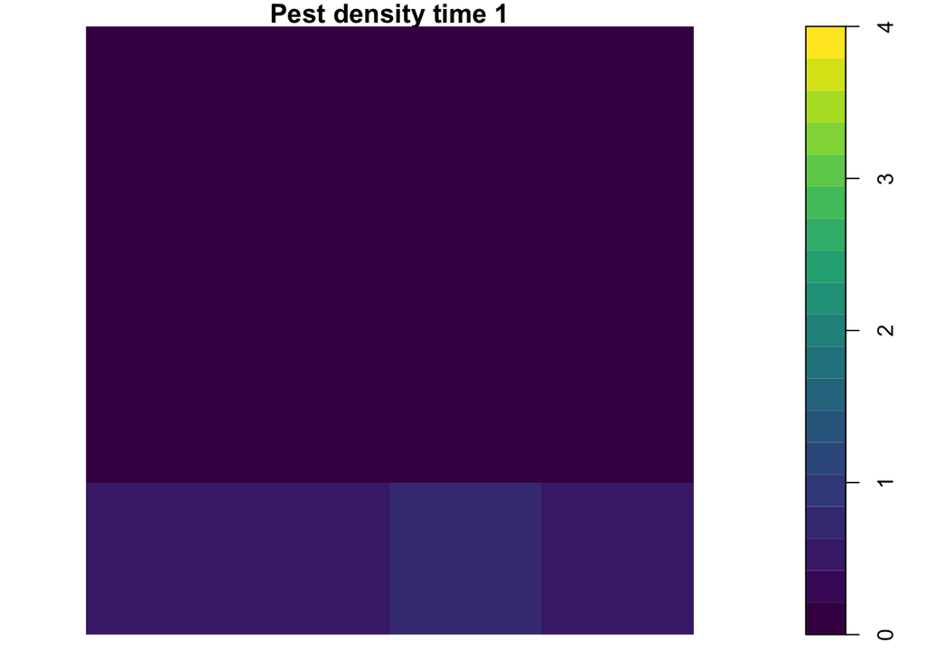

```r
plot(SpatialGridDataFrame(grid, data.frame(pest_den_nobudget[,1])), col=viridis(19), main="Pest density time 1",  breaks=seq(0,4,length.out=20)) # pest density without management
```

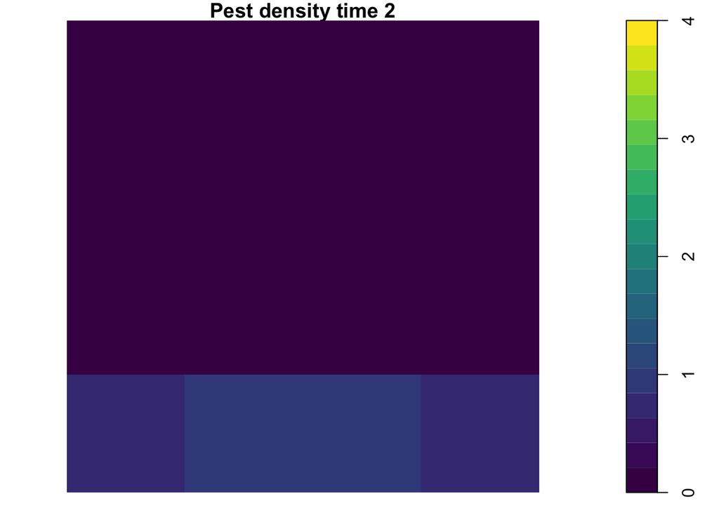

```r
plot(SpatialGridDataFrame(grid, data.frame(pest_den_nobudget[,2])), col=viridis(19), main="Pest density time 2",  breaks=seq(0,4,length.out=20)) # pest density without management
```

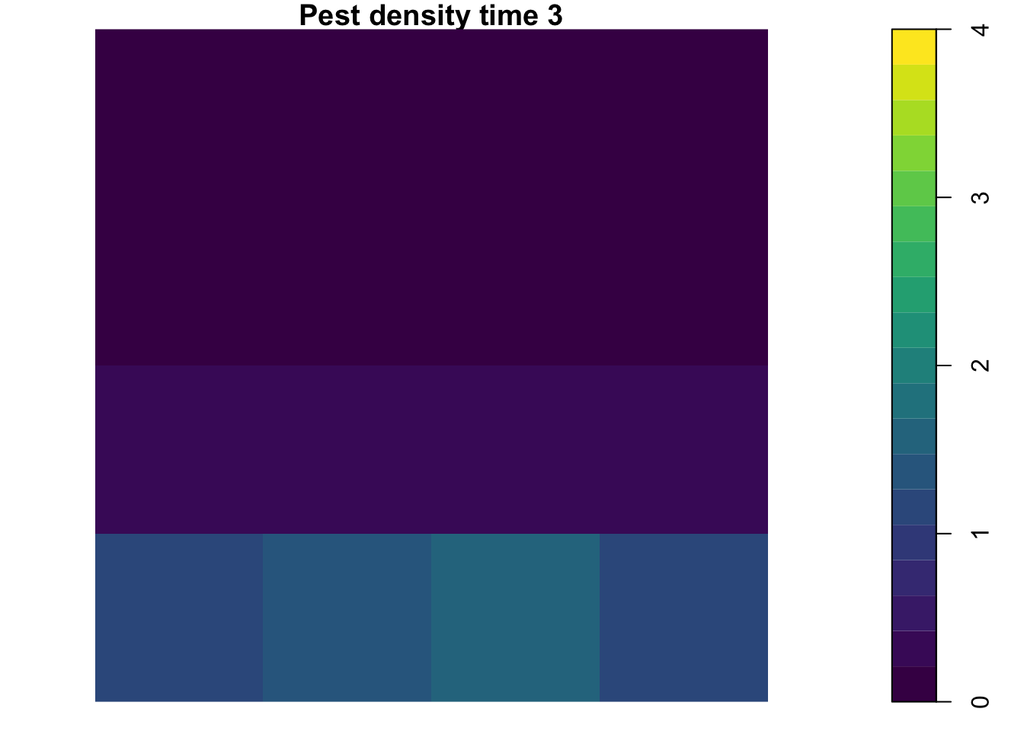

```r
plot(SpatialGridDataFrame(grid, data.frame(pest_den_nobudget[,3])), col=viridis(19), main="Pest density time 3",  breaks=seq(0,4,length.out=20)) # pest density without management
```

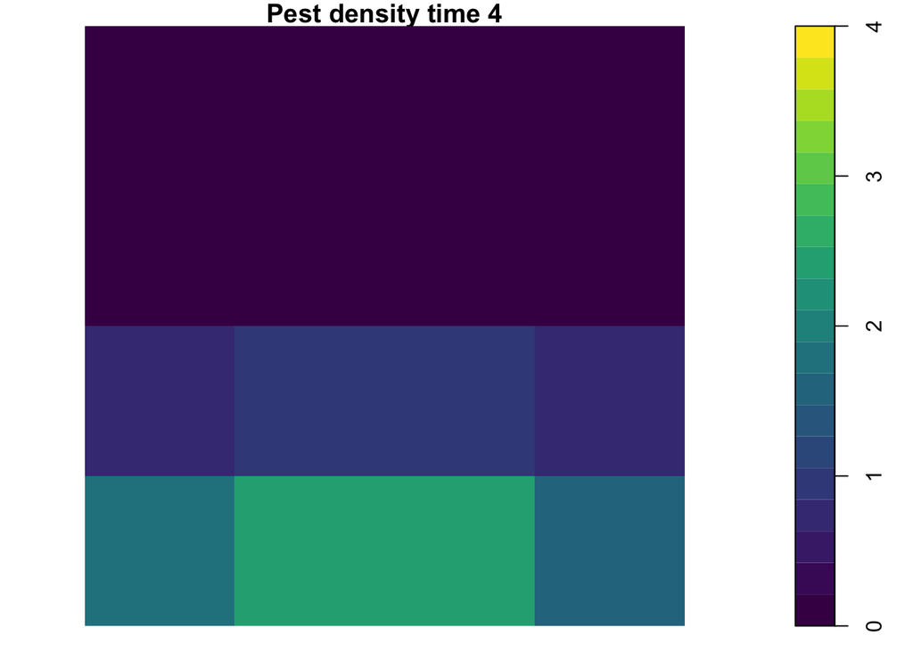

```r
plot(SpatialGridDataFrame(grid, data.frame(pest_den_nobudget[,4])), col=viridis(19), main="Pest density time 4",  breaks=seq(0,4,length.out=20)) # pest density without management
```

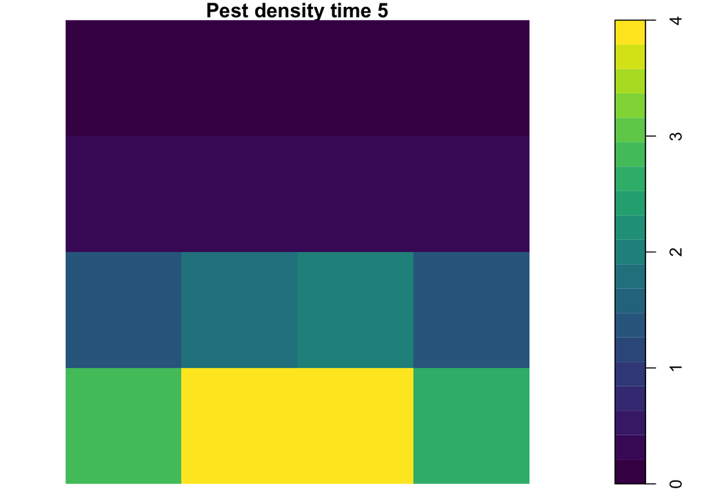

```r
plot(SpatialGridDataFrame(grid, data.frame(pest_den_nobudget[,5])), col=viridis(19), main="Pest density time 5",  breaks=seq(0,4,length.out=20)) # pest density without management
```

#### **Questions**

**(10)** How much did management reduce total pest density across space and time?

**(11)** Why might a site that has lower pest density at a given timestep be selected for management instead of one with higher pest density when accounting for dispersal? Think about how sites may get reinvaded from neighbouring sites.

**(12)** (optional if time) Describe which parameters you would change to improve the objective function further. If you are feeling brave, try changing these and resolving the model in the code chunk below!

**(13)** Discuss your overall results from this lab exercise as well as some potential applications of management optimization models.